# ADNI: Missing Data Imputation

ADNI dataset records participants’ information for each visit. However, there are plenty of missing entries in the dataset. Many research on Alzheimer’s trajectories prediction and classification tries to minify the influence of missing data using specific framework, like the Recurrent Neural Network. Also, some classification models just leave out the missing entries when training the models. It might be unwise to abandon any entries since we might find useful information in the patient’s record with missing data. A recent paper shows that with simple data imputation techniques, the classification performance can increase compared with removing the entries with missing data.

# Data preparation

We first prepare the subjects with fullly available biomarker and MRI information.

```r
library(ADNIMERGE)
library(tidyverse)
info_bio_mri <- c("RID","VISCODE","DX","AGE","PTGENDER","PTEDUCAT","PTETHCAT","PTRACCAT","PTMARRY","APOE4","FDG","ABETA","TAU","ADAS13","MMSE")
subjects_complete <- ADNIMERGE::adnimerge %>%
     select(info_bio_mri) %>%
     subset(VISCODE=="bl")%>%
     na.omit() %>%
     select(-c("RID","VISCODE"))
summary(subjects_complete)
```

```
        DX           AGE          PTGENDER            PTEDUCAT                PTETHCAT                PTRACCAT
 CN      :309   Min.   :55.00   Length:1002        Min.   : 4.00   Unknown        :  6   Am Indian/Alaskan:  2
 MCI     :517   1st Qu.:68.00   Class1:labelled    1st Qu.:14.00   Not Hisp/Latino:963   Asian            : 14
 Dementia:176   Median :73.30   Class2:character   Median :16.00   Hisp/Latino    : 33   Hawaiian/Other PI:  2
                Mean   :72.96   Mode  :character   Mean   :16.13                         Black            : 35
                3rd Qu.:77.90                      3rd Qu.:18.00                         White            :934
                Max.   :91.40                      Max.   :20.00                         More than one    : 13
                                                                                         Unknown          :  2
   PTMARRY              APOE4             FDG            ABETA               TAU                ADAS13
 Length:1002        Min.   :0.0000   Min.   :0.7215   Length:1002        Length:1002        Min.   : 0.00
 Class1:labelled    1st Qu.:0.0000   1st Qu.:1.1458   Class1:labelled    Class1:labelled    1st Qu.: 9.00
 Class2:character   Median :0.0000   Median :1.2497   Class2:character   Class2:character   Median :14.00
 Mode  :character   Mean   :0.5639   Mean   :1.2389   Mode  :character   Mode  :character   Mean   :16.22
                    3rd Qu.:1.0000   3rd Qu.:1.3402                                         3rd Qu.:21.59
                    Max.   :2.0000   Max.   :1.7011                                         Max.   :51.00

      MMSE
 Min.   :19.00
 1st Qu.:26.00
 Median :28.00
 Mean   :27.45
 3rd Qu.:29.00
 Max.   :30.00
```

Then we need to change those label like “>1700” to numeric values.

```r
subjects_complete[subjects_complete$ABETA == ">1700",]$ABETA <- 1700
subjects_complete$ABETA <- as.numeric(subjects_complete$ABETA)
subjects_complete[subjects_complete$TAU == ">1300",]$TAU <- 1300
subjects_complete$TAU <- as.numeric(subjects_complete$TAU)


subjects_complete[, 1] <- as.numeric(as.factor(subjects_complete[, 1]))
subjects_complete[, 3] <- as.numeric(as.factor(subjects_complete[, 3]))
subjects_complete[, 5] <- as.numeric(as.factor(subjects_complete[, 5]))
subjects_complete[, 6] <- as.numeric(as.factor(subjects_complete[, 6]))
subjects_complete[, 7] <- as.numeric(as.factor(subjects_complete[, 7]))
summary(subjects_complete)
```

```
       DX             AGE           PTGENDER        PTEDUCAT        PTETHCAT        PTRACCAT        PTMARRY
 Min.   :1.000   Min.   :55.00   Min.   :1.000   Min.   : 4.00   Min.   :1.000   Min.   :1.000   Min.   :1.00
 1st Qu.:1.000   1st Qu.:68.00   1st Qu.:1.000   1st Qu.:14.00   1st Qu.:2.000   1st Qu.:5.000   1st Qu.:2.00
 Median :2.000   Median :73.30   Median :2.000   Median :16.00   Median :2.000   Median :5.000   Median :2.00
 Mean   :1.867   Mean   :72.96   Mean   :1.557   Mean   :16.13   Mean   :2.027   Mean   :4.928   Mean   :2.27
 3rd Qu.:2.000   3rd Qu.:77.90   3rd Qu.:2.000   3rd Qu.:18.00   3rd Qu.:2.000   3rd Qu.:5.000   3rd Qu.:2.00
 Max.   :3.000   Max.   :91.40   Max.   :2.000   Max.   :20.00   Max.   :3.000   Max.   :7.000   Max.   :5.00
     APOE4             FDG             ABETA             TAU              ADAS13           MMSE
 Min.   :0.0000   Min.   :0.7215   Min.   : 203.0   Min.   :  81.54   Min.   : 0.00   Min.   :19.00
 1st Qu.:0.0000   1st Qu.:1.1458   1st Qu.: 634.1   1st Qu.: 192.07   1st Qu.: 9.00   1st Qu.:26.00
 Median :0.0000   Median :1.2497   Median : 877.0   Median : 256.55   Median :14.00   Median :28.00
 Mean   :0.5639   Mean   :1.2389   Mean   :1002.6   Mean   : 285.35   Mean   :16.22   Mean   :27.45
 3rd Qu.:1.0000   3rd Qu.:1.3402   3rd Qu.:1430.2   3rd Qu.: 343.38   3rd Qu.:21.59   3rd Qu.:29.00
 Max.   :2.0000   Max.   :1.7011   Max.   :1700.0   Max.   :1300.00   Max.   :51.00   Max.   :30.00
```

# Define helper functions

Define a function that can randomly mask the biomarker data according to the input arguments. Should define the boundaries of masked value, percentage of missingness and the orignal table.

```r
gen_mask <- function(table, percentage, col_start, col_end, ...) {
   col_num <- col_end - col_start
   table_return <- table
   row_num <- nrow(table)
   table_return[, c(col_start:col_end)] <- apply (table[, c(col_start:col_end)], 2, function(x) {x[sample( c(1:row_num), row_num*percentage/col_num)] <- NA; x} )
   return(table_return)
}

 View(gen_mask(subjects_complete, 0.5, 9, 11))
```

For this application, define a helper function that takes only an input table and percentage.

```r
gen_mask_app <- function(table, percentage = 0.4, ...){
  return(gen_mask(table,percentage,9,11))
}
```

Define a function that can calculate the imputation error rate.

```r
error_rate <- function(table_comp, table_imput, table_missing, ...){
  table_comp_use <- as.data.frame(table_comp[, c(9:11)])
  table_imput_use <- as.data.frame(table_imput[, c(9:11)])
  table_missing_use <- as.data.frame(table_missing[, c(9:11)])
  return(sum((table_comp_use[is.na(table_missing_use)] - table_imput_use[is.na(table_missing_use)])^2) / sum(table_comp_use[is.na(table_missing_use)]^2))
}
```

# PPCA and BPCA imputation pipeline

```r
library(pcaMethods)
ppca_imputation <- function(mD, ...){
  pc <- pca(mD, nPcs=3, method="ppca")
  return(completeObs(pc))

}
```

```r
library(pcaMethods)
bpca_imputation <- function(mD, ...){
    pc <- pca(mD, nPcs=2, method="bpca")
    return(completeObs(pc))
}
```

# MICE Imputation Pipeline

```r
library(mice)
mice_imputation <- function(mD, ...){
  mc <- mice(mD)
  return(complete(mc))
}
```

# RF Imputation

```r
library(missForest)
rf_imputation <- function(md, ...){
  md1 <- data.matrix(md)
  return(missForest(md1, verbose = FALSE)$ximp)
}
```

# NNLM

```r
library(NNLM)
nnmf_imputation <- function(mD, ...){

  # impute using NMF
  mD1 <- data.matrix(mD)
  system.time(mD1.nmf <- nnmf(mD1, 2))
  return( with(mD1.nmf, W %*% H))
}
```

```r
iterate_calc <- function(func, start, end, step, ...){
  mD <- gen_mask_app(subjects_complete, start)
  currentVal <- error_rate(subjects_complete, func(mD), mD)
  if(start + step <= end){
    followingVec <- iterate_calc(func, start+step, end, step)

  }else{
    return(c(currentVal))

  }
  return(prepend(followingVec,currentVal))
}
```

```r
ppca_result <- iterate_calc(ppca_imputation,0.05,0.51,0.01)
```

[output not shown]

```r
bpca_result <- iterate_calc(ppca_imputation,0.05,0.51,0.01)
```

[output not shown]

```r
mice_result <- iterate_calc(ppca_imputation,0.05,0.51,0.01)
```

[output not shown]

```r
rf_result <- iterate_calc(ppca_imputation,0.05,0.51,0.01)
```

[output not shown]

```r
nnmf_result <- iterate_calc(ppca_imputation,0.05,0.51,0.01)
```

[output not shown]

```r
total_vec <- c(ppca_result, bpca_result, mice_result, rf_result, nnmf_result)
results<- matrix(total_vec, nrow = 5,ncol = 46)

plot(NULL, xlim = c(0.05,0.5), ylim = c(0, 0.5), xlab = 'missingness', ylab = 'error rate');
lines(seq(0.05,0.5,by=0.01), ppca_result, col = 'firebrick1');
```

```r
lines(seq(0.05,0.5,by=0.01), bpca_result, col = 'orange');
lines(seq(0.05,0.5,by=0.01), mice_result, col = 'chartreuse3');
```

```r
lines(seq(0.05,0.5,by=0.01), nnmf_result, col = 'deepskyblue4');
lines(seq(0.05,0.5,by=0.01), rf_result, col = 'orange');
```

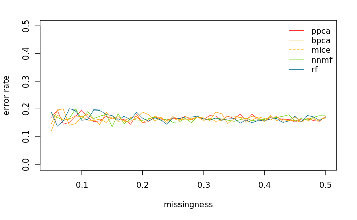

```r
legend('topright', bty = 'n', lwd = 1, lty = c(1,1,2,1,1),
legend = c('ppca', 'bpca', 'mice', 'nnmf', 'rf'),
col = c('firebrick1', 'orange', 'orange', 'chartreuse3', 'deepskyblue4'))
```